# Home Depot (HD): Time-Series Stylised Facts, CAPM/APT, ARMA & GARCH

**Author:** Yurui Qiu · Personal project

## Executive Summary

This project shows that HD return **levels** are hard to forecast, but return **volatility** is predictable. ARMA barely improves point forecasts over a white-noise benchmark, while the Engle ARCH-LM test and GARCH(1,1) results show strong conditional heteroskedasticity. The main takeaway is that **risk modelling is more useful than point-return prediction** for this asset -- which has direct implications for Value-at-Risk and options pricing, where the object of interest is the width of the distribution rather than its centre.

This notebook:

1. Pulls HD daily/hourly prices and computes log-returns
2. Examines stylised facts (volatility clustering, fat tails, non-normality)
3. Verifies data sources against the Fama-French library
4. Estimates CAPM and a Fama-French five-factor + momentum + oil APT model
5. Fits an ARMA model for the conditional mean and evaluates it out-of-sample
6. Formally tests for ARCH effects and fits a GARCH(1,1) model for the conditional variance, then compares ARMA-only vs ARMA+GARCH interval forecasts

## 0. Setup

## 1. Load price data and compute log-returns

```
(Date
 2026-06-29    0.005574
 2026-06-30    0.005316
 2026-07-01   -0.005231
 2026-07-02    0.019923
 2026-07-06   -0.020465
 Name: log_return, dtype: float64,
 Datetime
 2026-07-06 15:30:00+00:00    0.004581
 2026-07-06 16:30:00+00:00    0.003223
 2026-07-06 17:30:00+00:00    0.001536
 2026-07-06 18:30:00+00:00   -0.003047
 2026-07-06 19:30:00+00:00    0.000086
 Name: log_return, dtype: float64)
```

## 2. Stylised facts

### 2a. Return series plots

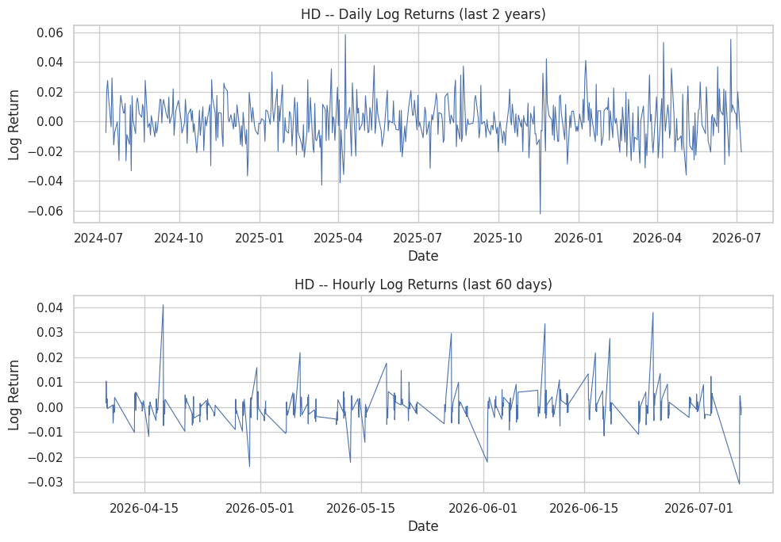

### 2b. Distributional properties

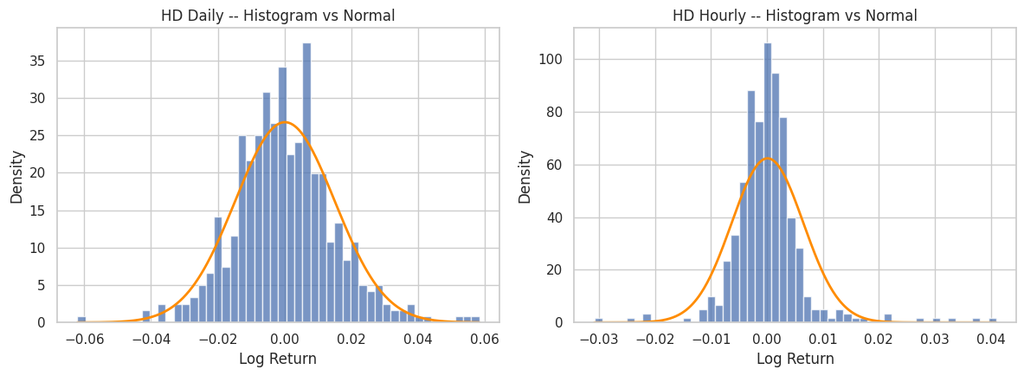

|  | Daily | Hourly |
| --- | --- | --- |
| Mean | 0.000150 | 0.000125 |
| Std Dev | 0.014921 | 0.006406 |
| Skewness | 0.215516 | 1.523762 |
| Excess Kurtosis | 1.323693 | 11.701335 |

## 3. Data matching and verification

Assembles HD returns, S&P 500 returns, the 13-week T-bill rate (`^IRX`), and the Fama-French five factors + momentum, and checks the sources are consistent with each other before using them downstream.

| Date | HD_ret | MKT_ret | Tbill_annual |
| --- | --- | --- | --- |
| 1981-09-23 | 0.0 | -0.008828 | 0.1420 |
| 1981-09-24 | 0.0 | -0.005534 | 0.1421 |
| 1981-09-25 | 0.0 | -0.019477 | 0.1430 |
| 1981-09-28 | 0.0 | 0.024475 | 0.1412 |
| 1981-09-29 | 0.0 | 0.003549 | 0.1416 |

```
Merged panel: (11201, 10) 1981-09-23 00:00:00 --> 2026-05-29 00:00:00
```

| Date | HD_ret | MKT_ret | Tbill_annual | Mkt-RF | SMB | HML | RMW | CMA | RF | MOM |
| --- | --- | --- | --- | --- | --- | --- | --- | --- | --- | --- |
| 1981-09-23 | 0.0 | -0.008828 | 0.1420 | -0.0122 | -0.0093 | 0.0091 | 0.0009 | 0.0038 | 0.0006 | 0.0048 |
| 1981-09-24 | 0.0 | -0.005534 | 0.1421 | -0.0039 | 0.0032 | 0.0018 | -0.0002 | -0.0006 | 0.0006 | 0.0038 |
| 1981-09-25 | 0.0 | -0.019477 | 0.1430 | -0.0240 | -0.0111 | 0.0175 | -0.0023 | 0.0074 | 0.0006 | 0.0058 |
| 1981-09-28 | 0.0 | 0.024475 | 0.1412 | 0.0194 | -0.0182 | -0.0159 | 0.0108 | -0.0124 | 0.0006 | -0.0022 |
| 1981-09-29 | 0.0 | 0.003549 | 0.1416 | 0.0085 | 0.0152 | -0.0126 | -0.0001 | -0.0038 | 0.0006 | 0.0012 |

### 3a. S&P 500 excess return vs Fama-French market excess return

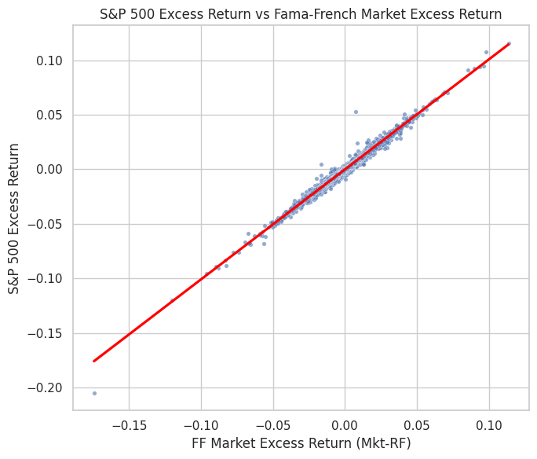

### 3b. T-bill rate vs Fama-French risk-free rate

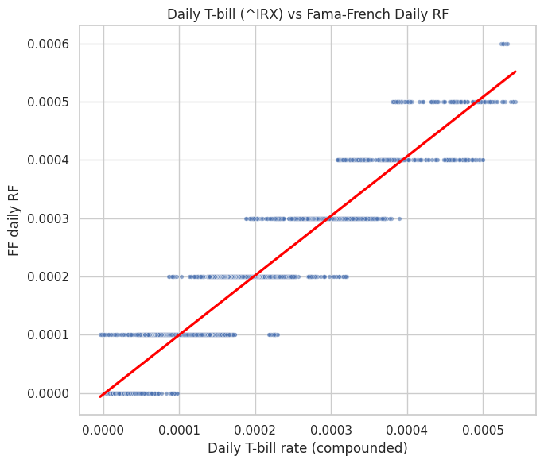

## 4. CAPM

```
                            OLS Regression Results
==============================================================================
Dep. Variable:              HD_excess   R-squared:                       0.284
Model:                            OLS   Adj. R-squared:                  0.284
Method:                 Least Squares   F-statistic:                     4451.
Date:                Tue, 07 Jul 2026   Prob (F-statistic):               0.00
Time:                        08:31:11   Log-Likelihood:                 28392.
No. Observations:               11201   AIC:                        -5.678e+04
Df Residuals:                   11199   BIC:                        -5.677e+04
Df Model:                           1
Covariance Type:            nonrobust
==============================================================================
                 coef    std err          t      P>|t|      [0.025      0.975]
------------------------------------------------------------------------------
const          0.0006      0.000      3.092      0.002       0.000       0.001
Mkt-RF         1.0885      0.016     66.713      0.000       1.057       1.120
==============================================================================
Omnibus:                     3959.998   Durbin-Watson:                   2.027
Prob(Omnibus):                  0.000   Jarque-Bera (JB):           559711.042
Skew:                           0.625   Prob(JB):                         0.00
Kurtosis:                      37.608   Cond. No.                         90.0
==============================================================================

Notes:
[1] Standard Errors assume that the covariance matrix of the errors is correctly specified.
beta = 1.089, alpha = 0.00056
```

|  | Replication Portfolio | Home Depot (HD) |
| --- | --- | --- |
| Mean E[R] | 0.000543 | 0.001104 |
| Variance | 0.000146 | 0.000514 |
| Sharpe Ratio | 0.033145 | 0.042397 |

## 5. Arbitrage Pricing Theory (Fama-French five-factor + momentum + oil)

```
                            OLS Regression Results
==============================================================================
Dep. Variable:              HD_excess   R-squared:                       0.294
Model:                            OLS   Adj. R-squared:                  0.294
Method:                 Least Squares   F-statistic:                     933.6
Date:                Tue, 07 Jul 2026   Prob (F-statistic):               0.00
Time:                        08:31:11   Log-Likelihood:                 28470.
No. Observations:               11201   AIC:                        -5.693e+04
Df Residuals:                   11195   BIC:                        -5.688e+04
Df Model:                           5
Covariance Type:            nonrobust
==============================================================================
                 coef    std err          t      P>|t|      [0.025      0.975]
------------------------------------------------------------------------------
const          0.0005      0.000      2.583      0.010       0.000       0.001
Mkt-RF         1.1446      0.018     64.373      0.000       1.110       1.179
SMB            0.0944      0.032      2.954      0.003       0.032       0.157
HML           -0.0902      0.033     -2.744      0.006      -0.155      -0.026
RMW            0.5415      0.044     12.353      0.000       0.456       0.627
CMA           -0.0200      0.055     -0.367      0.714      -0.127       0.087
==============================================================================
Omnibus:                     3958.066   Durbin-Watson:                   2.032
Prob(Omnibus):                  0.000   Jarque-Bera (JB):           584512.017
Skew:                           0.610   Prob(JB):                         0.00
Kurtosis:                      38.368   Cond. No.                         323.
==============================================================================

Notes:
[1] Standard Errors assume that the covariance matrix of the errors is correctly specified.
```

```
FF5 adj. R^2 = 0.294 | FF5+MOM adj. R^2 = 0.294
                            OLS Regression Results
==============================================================================
Dep. Variable:              HD_excess   R-squared:                       0.295
Model:                            OLS   Adj. R-squared:                  0.294
Method:                 Least Squares   F-statistic:                     778.9
Date:                Tue, 07 Jul 2026   Prob (F-statistic):               0.00
Time:                        08:31:11   Log-Likelihood:                 28472.
No. Observations:               11201   AIC:                        -5.693e+04
Df Residuals:                   11194   BIC:                        -5.688e+04
Df Model:                           6
Covariance Type:            nonrobust
==============================================================================
                 coef    std err          t      P>|t|      [0.025      0.975]
------------------------------------------------------------------------------
const          0.0005      0.000      2.661      0.008       0.000       0.001
Mkt-RF         1.1401      0.018     63.643      0.000       1.105       1.175
SMB            0.0922      0.032      2.886      0.004       0.030       0.155
HML           -0.1163      0.035     -3.293      0.001      -0.186      -0.047
RMW            0.5439      0.044     12.403      0.000       0.458       0.630
CMA            0.0016      0.056      0.029      0.977      -0.107       0.111
MOM           -0.0454      0.022     -2.023      0.043      -0.089      -0.001
==============================================================================
Omnibus:                     3951.213   Durbin-Watson:                   2.031
Prob(Omnibus):                  0.000   Jarque-Bera (JB):           583703.475
Skew:                           0.607   Prob(JB):                         0.00
Kurtosis:                      38.344   Cond. No.                         335.
==============================================================================

Notes:
[1] Standard Errors assume that the covariance matrix of the errors is correctly specified.
```

```
FF5+MOM adj. R^2 = 0.294 | +Oil adj. R^2 = 0.456
                            OLS Regression Results
==============================================================================
Dep. Variable:              HD_excess   R-squared:                       0.457
Model:                            OLS   Adj. R-squared:                  0.456
Method:                 Least Squares   F-statistic:                     774.2
Date:                Tue, 07 Jul 2026   Prob (F-statistic):               0.00
Time:                        08:31:12   Log-Likelihood:                 18633.
No. Observations:                6458   AIC:                        -3.725e+04
Df Residuals:                    6450   BIC:                        -3.720e+04
Df Model:                           7
Covariance Type:            nonrobust
==============================================================================
                 coef    std err          t      P>|t|      [0.025      0.975]
------------------------------------------------------------------------------
const       3.995e-05      0.000      0.237      0.813      -0.000       0.000
Mkt-RF         1.0487      0.016     67.320      0.000       1.018       1.079
SMB            0.0855      0.029      2.985      0.003       0.029       0.142
HML           -0.0587      0.028     -2.115      0.034      -0.113      -0.004
RMW            0.3888      0.036     10.694      0.000       0.317       0.460
CMA            0.1703      0.047      3.607      0.000       0.078       0.263
MOM           -0.0948      0.018     -5.248      0.000      -0.130      -0.059
Oil_ret       -0.0198      0.003     -5.685      0.000      -0.027      -0.013
==============================================================================
Omnibus:                     2932.334   Durbin-Watson:                   1.976
Prob(Omnibus):                  0.000   Jarque-Bera (JB):           236851.294
Skew:                          -1.283   Prob(JB):                         0.00
Kurtosis:                      32.557   Cond. No.                         299.
==============================================================================

Notes:
[1] Standard Errors assume that the covariance matrix of the errors is correctly specified.
```

|  | Variable | VIF |
| --- | --- | --- |
| 0 | Mkt-RF | 1.284974 |
| 1 | SMB | 1.142253 |
| 2 | HML | 1.629618 |
| 3 | RMW | 1.279924 |
| 4 | CMA | 1.522584 |
| 5 | MOM | 1.284449 |
| 6 | Oil_ret | 1.027218 |

## 6. ARMA model for the conditional mean

### 6a. ACF / PACF of returns and squared returns

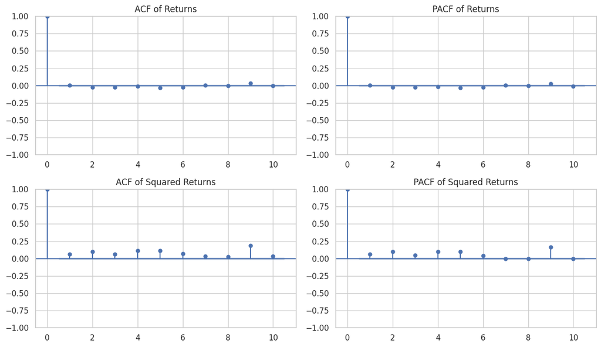

### 6b. Grid search over low-order ARMA(p,q) specifications

|  | order | aic | bic |
| --- | --- | --- | --- |
| 7 | (2, 1) | -53041.012919 | -53004.395020 |
| 5 | (1, 2) | -53035.646339 | -52999.028886 |
| 4 | (1, 1) | -53028.143334 | -52998.849015 |
| 8 | (2, 2) | -53025.848419 | -52981.907476 |
| 0 | (0, 0) | -53024.074460 | -53009.427122 |
| 3 | (1, 0) | -53022.412830 | -53000.441823 |
| 6 | (2, 0) | -53021.671247 | -52992.376928 |
| 1 | (0, 1) | -53016.691596 | -52994.720856 |
| 2 | (0, 2) | -53015.989657 | -52986.695695 |

```
Selected ARMA(2, 1) by AIC
                               SARIMAX Results
==============================================================================
Dep. Variable:                 HD_ret   No. Observations:                11201
Model:                 ARIMA(2, 0, 1)   Log Likelihood               26525.506
Date:                Tue, 07 Jul 2026   AIC                         -53041.013
Time:                        08:32:46   BIC                         -53004.395
Sample:                             0   HQIC                        -53028.687
                              - 11201
Covariance Type:                  opg
==============================================================================
                 coef    std err          z      P>|z|      [0.025      0.975]
------------------------------------------------------------------------------
const          0.0009      0.000      3.889      0.000       0.000       0.001
ar.L1          0.9986      0.006    167.027      0.000       0.987       1.010
ar.L2         -0.0032      0.006     -0.527      0.598      -0.015       0.009
ma.L1         -1.0040      0.001   -840.816      0.000      -1.006      -1.002
sigma2         0.0005    2.2e-06    231.452      0.000       0.001       0.001
===================================================================================
Ljung-Box (L1) (Q):                   0.00   Jarque-Bera (JB):            209147.28
Prob(Q):                              0.99   Prob(JB):                         0.00
Heteroskedasticity (H):               0.27   Skew:                             0.18
Prob(H) (two-sided):                  0.00   Kurtosis:                        24.17
===================================================================================

Warnings:
[1] Covariance matrix calculated using the outer product of gradients (complex-step).
```

### 6c. Residual diagnostics: Ljung-Box and BDS

```
Ljung-Box p(lag=10) = 5.267e-08
Ljung-Box p(lag=20) = 5.346e-10
Ljung-Box p(lag=30) = 1.143e-07
```

```
BDS test (non-linear dependence in standardized residuals):
   m   BDS stat        p-value
0  2  26.379034  2.384558e-153
1  3  31.898091  2.837852e-223
2  4  35.567438  4.467017e-277
3  5  38.486131   0.000000e+00
4  6  40.871262   0.000000e+00
```

### 6d. Long-run forecast

```
Analytical long-run mean = 0.608303
```

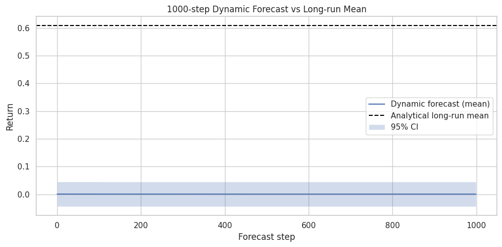

**Caveat on the long-run mean above:** the selected ARMA(2,1) has AR coefficients that sum to approximately 0.995 -- very close to the non-stationarity boundary. The analytical long-run mean formula divides by `(1 - sum of AR coefficients)`, so a denominator this close to zero makes the resulting estimate numerically unstable and **not economically meaningful** (a daily mean return on the order of tens of percent is not plausible). The out-of-sample RMSE comparison in Section 6e-f is a more reliable way to judge this model's forecasting value than the long-run mean estimate.

### 6e-f. Out-of-sample evaluation vs a white-noise benchmark

```
ARMA(2, 1) RMSE      = 0.016809
White-noise RMSE          = 0.016809
ARMA beats white noise
```

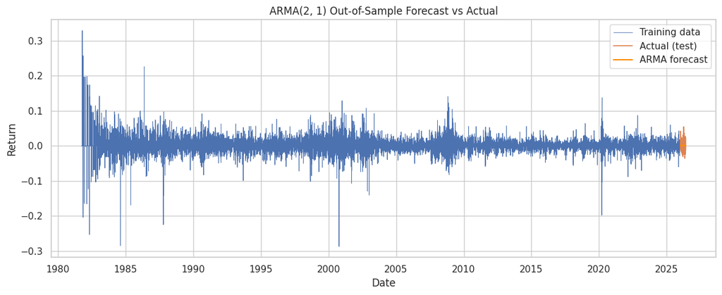

## 7. Extension: formal ARCH test and GARCH(1,1) volatility model

Section 6's residual diagnostics showed persistent autocorrelation in squared residuals and a BDS test that strongly rejects i.i.d. residuals -- both signs of conditional heteroskedasticity that an ARMA mean model cannot capture on its own. This section follows up on that: it formally tests for ARCH effects (rather than relying on visual inspection of the ACF), fits a GARCH(1,1) on top of the chosen ARMA mean model, and compares the resulting interval forecasts with the ARMA-only intervals used in Section 6.

### 7a. Engle's ARCH-LM test

```
Engle ARCH-LM statistic = 674.83, p-value = 1.589e-138
Reject homoskedasticity -> conditional variance should be modelled explicitly.
```

### 7b. Fit GARCH(1,1) on the ARMA residuals

```
                          Zero Mean - GARCH Model Results
====================================================================================
Dep. Variable:                         None   R-squared:                       0.000
Mean Model:                       Zero Mean   Adj. R-squared:                  0.000
Vol Model:                            GARCH   Log-Likelihood:               -22301.4
Distribution:      Standardized Student's t   AIC:                           44610.8
Method:                  Maximum Likelihood   BIC:                           44640.1
                                              No. Observations:                11201
Date:                      Tue, Jul 07 2026   Df Residuals:                    11201
Time:                              08:33:41   Df Model:                            0
                              Volatility Model
============================================================================
                 coef    std err          t      P>|t|      95.0% Conf. Int.
----------------------------------------------------------------------------
omega          0.0308  7.814e-03      3.942  8.081e-05 [1.549e-02,4.612e-02]
alpha[1]       0.0659  9.421e-03      6.999  2.575e-12 [4.748e-02,8.441e-02]
beta[1]        0.9296  9.927e-03     93.637      0.000     [  0.910,  0.949]
                              Distribution
========================================================================
                 coef    std err          t      P>|t|  95.0% Conf. Int.
------------------------------------------------------------------------
nu             5.1147      0.258     19.822  1.927e-87 [  4.609,  5.620]
========================================================================

Covariance estimator: robust
```

### 7c. Conditional volatility and ARMA vs ARMA-GARCH interval forecasts

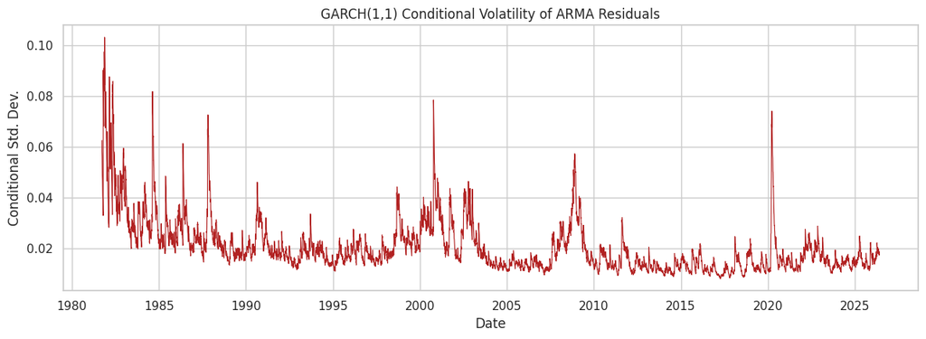

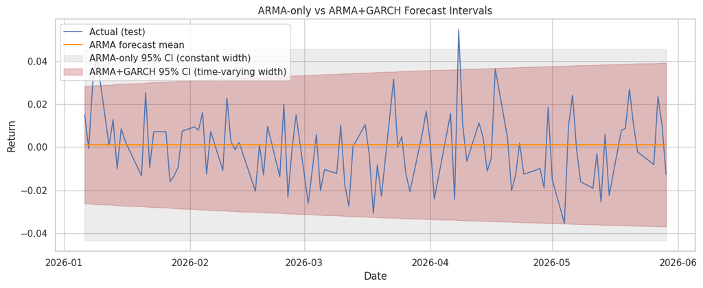

```
Mean ARMA-only interval half-width   = 0.04453 (constant)
Mean ARMA+GARCH interval half-width  = 0.03333 (time-varying, range 0.02719-0.03805)
```

### 7d. Interpretation

If the GARCH-based intervals widen around volatile periods and narrow during calm periods (rather than the constant-width ARMA-only band), that confirms the conclusion from Sections 6 and 7a: the conditional **mean** of HD's returns is close to white noise (ARMA barely beats it), but the conditional **variance** is genuinely time-varying and worth modelling separately for risk-management purposes such as Value-at-Risk.